# STATS-506-Homework-4

https://github.com/TransparentBlu3/STATS-506-Homework-4

Author

Yiping Wang

# Problem 1

```r
library(tidyverse)
library(nzelect)
df <- nzge
```

## a.

```r
tibble(df %>%
         group_by(voting_type, election_year) %>%
         summarise(count = sum(votes)) %>%
         arrange(count))
```

```
# A tibble: 10 × 3
   voting_type election_year   count
   <chr>               <dbl>   <dbl>
 1 Candidate            2002 2022115
 2 Party                2002 2040248
 3 Candidate            2011 2225766
 4 Party                2011 2257336
 5 Candidate            2005 2260670
 6 Party                2005 2286190
 7 Candidate            2008 2325598
 8 Party                2008 2356536
 9 Candidate            2014 2375493
10 Party                2014 2416479
```

## b.

```r
tibble(df %>%
         filter(election_year == 2014) %>%
         group_by(party) %>%
         summarise(count = sum(votes),
                   proportion = count/sum(df[df$election_year == 2014,]$votes)) %>%
         select(-count) %>%
         arrange(proportion))
```

```
# A tibble: 28 × 2
   party                         proportion
   <chr>                              <dbl>
 1 Patriotic Revolutionary Front  0.0000100
 2 NZ Economic Euthenics Party    0.0000106
 3 Alliance                       0.0000123
 4 The Expats                     0.0000146
 5 Human Rights Party             0.0000159
 6 Climate Party                  0.0000242
 7 Communist League               0.0000282
 8 Money Free Party               0.0000816
 9 The Civilian Party             0.000229
10 Focus New Zealand              0.000508
# ℹ 18 more rows
```

## c.

```r
df_votecounts <- df %>%
  group_by(voting_type, election_year, party) %>%
  summarise(count = sum(votes))
df_ref <- df_votecounts %>%
  group_by(voting_type, election_year)%>%
  summarise(max = max(count))
df_results <- df_votecounts %>%
  left_join(df_ref, by = join_by(voting_type, election_year)) %>%
  filter(count == max) %>%
  select(election_year, party, voting_type)%>%
  arrange(election_year)
tibble(df_results)
```

```
# A tibble: 10 × 3
   election_year party          voting_type
           <dbl> <chr>          <chr>
 1          2002 Labour Party   Candidate
 2          2002 Labour Party   Party
 3          2005 National Party Candidate
 4          2005 Labour Party   Party
 5          2008 National Party Candidate
 6          2008 National Party Party
 7          2011 National Party Candidate
 8          2011 National Party Party
 9          2014 National Party Candidate
10          2014 National Party Party
```

# Problem 2

```r
atp_matches <- read.csv("atp_matches_2019.csv")
```

## a.

```r
nrow(atp_matches %>%
       group_by(tourney_id, tourney_name) %>%
       count())
```

```
[1] 128
```

There were total of 128 tournaments that took place in 2019.

## b.

```r
atp_matches %>%
  filter(round == "F") %>%
  dim()
```

```
[1] 67 49
```

There were only 67 tournaments with a final game, but remembering that we have 128 total, so if we check for the rest, we can see that they are all listed round “RR”. I do not know about tennis, so I searched online. My search results indicate that the winner of any RR round does not indicate winning the whole tournament, instead, the player with the most wins would be the champion. Therefore, I used an if and else statement in the following code to spot the winners of all of the tournaments.

```r
wincount <- atp_matches %>%
  group_by(tourney_id, tourney_name) %>%
  summarise(winner = if(any(round == "F")) {
    winner_name[round == "F"]
  } else {
    winner_counts = table(winner_name)
    names(which.max(winner_counts))
  }) %>%
  ungroup() %>%
  group_by(winner) %>%
  summarise(wincount = n()) %>%
  filter(wincount > 1)
wincount %>%
  nrow()
```

```
[1] 22
```

```r
wincount %>%
  arrange(desc(wincount)) %>%
  head(1)
```

```
# A tibble: 1 × 2
  winner         wincount
  <chr>             <int>
1 Alex De Minaur        7
```

Yes, there were total of 22 players wining more than one tournament and the most winning player won 7 tournaments total.

## c.

```r
atp_matches %>%
  select(w_ace, l_ace) %>%
  pivot_longer(cols = c(w_ace, l_ace),
               names_to = "result",
               values_to = "aces") %>%
  group_by(result) %>%
  summarise(mean_aces = mean(aces, na.rm = TRUE),
            sd_aces = sd(aces, na.rm = TRUE)) %>%
  ungroup()%>%
  mutate(meandiff = mean_aces[2] - mean_aces[1],
  se = sqrt((sd_aces[2]^2 / nrow(atp_matches)) + (sd_aces[1]^2 / nrow(atp_matches))),
  t = meandiff / se,
  df = nrow(atp_matches) - 1,
  p_value = 1 - pt(t, df)) %>%
  pivot_wider(names_from = result, values_from = c(mean_aces, sd_aces))
```

```
# A tibble: 1 × 9
  meandiff    se     t    df p_value mean_aces_l_ace mean_aces_w_ace
     <dbl> <dbl> <dbl> <dbl>   <dbl>           <dbl>           <dbl>
1     1.70 0.156  10.9  2805       0            5.79            7.50
# ℹ 2 more variables: sd_aces_l_ace <dbl>, sd_aces_w_ace <dbl>
```

Applying the one-tail t test, we can see that the p-value is smaller than $\alpha = 0.05$. Therefore, we say that we have enough evidence to reject the NULL and accept the alternative that winners have significantly more aces than losers at $\alpha = 0.05$.

## d.

```r
atp_matches %>%
  select(winner_id, loser_id, winner_name, loser_name) %>%
  pivot_longer(cols = c(winner_id, loser_id, winner_name, loser_name), names_to = c("result", ".value"), names_sep = "_") %>%
  group_by(id, name) %>%
  summarise(matchcount = n(),
            wincount = sum(result == "winner"),
            winrate = wincount/matchcount) %>%
  filter(matchcount >= 5) %>%
  arrange(desc(winrate)) %>%
  select(name, winrate) %>%
  head(1)
```

[output not shown]

```
# A tibble: 1 × 3
# Groups:   id [1]
      id name         winrate
   <int> <chr>          <dbl>
1 104745 Rafael Nadal   0.870
```

The player with the highest win-rate is Rafael Nadal with an approximately 87% win-rate.

# Problem 3

```r
covid_df <- read.csv("us-states.csv")
covid_df$date <- as.Date(covid_df$date)
```

## a.

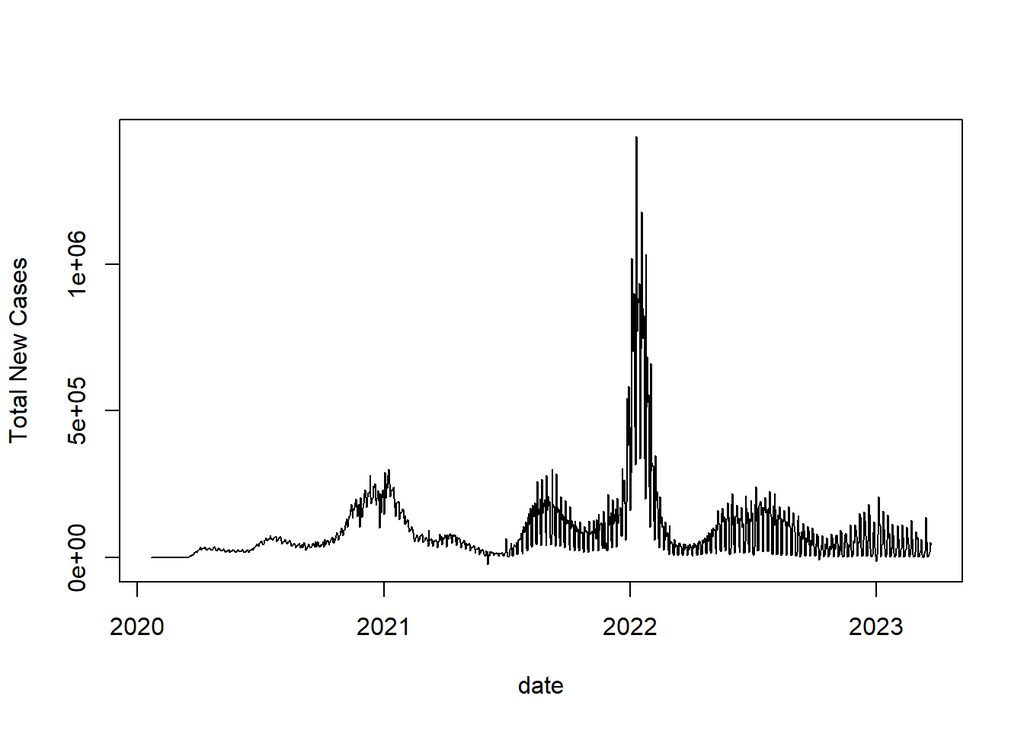

```r
covid_us <- covid_df %>%
  group_by(date)%>%
  mutate(total_newcases = sum(cases))
with(covid_us, plot(total_newcases ~ date, type = "l", ylab = "Total New Cases"))
```

From merely looking at the plot, we can find 4 minor spikes between 2021 and 2023 and 1 major spike at 2022.

## b.

```r
covid_df1 <- covid_df %>%
  group_by(state) %>%
  mutate(cases_overall_population = sum(cases_avg_per_100k))
covid_df1$state[which.max(covid_df1$cases_overall_population)]
```

```
[1] "Rhode Island"
```

```r
covid_df1$state[which.min(covid_df1$cases_overall_population)]
```

```
[1] "Maine"
```

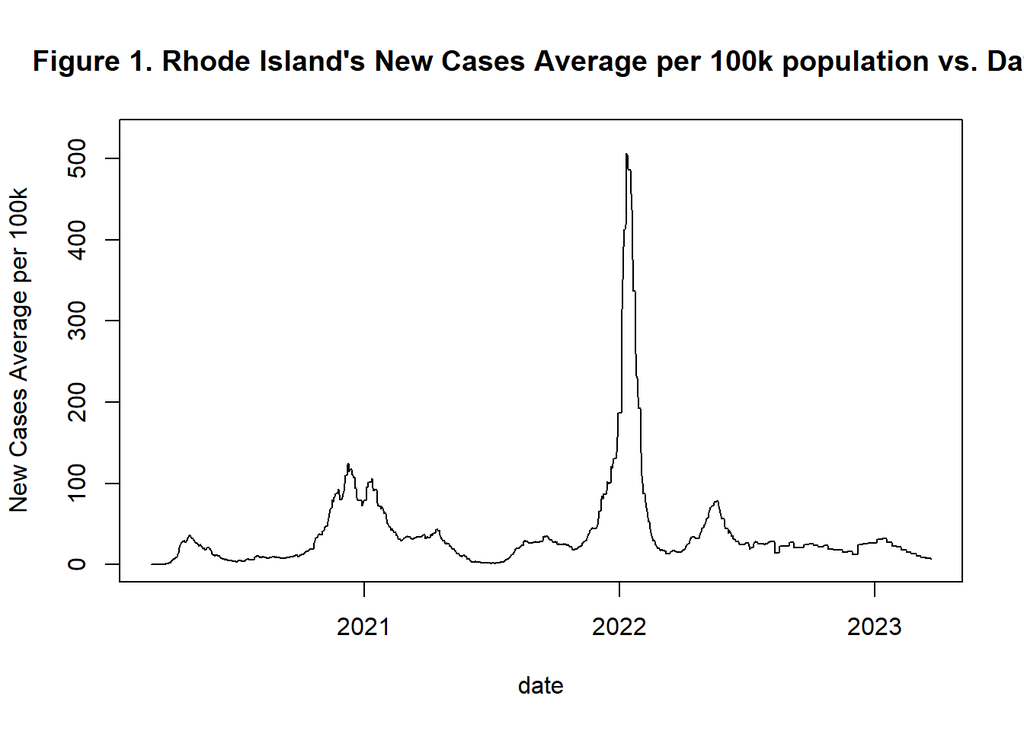

```r
with(covid_df[covid_df$state == "Rhode Island", ], plot(cases_avg_per_100k ~ date, ylim = c(min(covid_df$cases_avg_per_100k), max(covid_df$cases_avg_per_100k)), type = "l", main = "Figure 1. Rhode Island's New Cases Average per 100k population vs. Date", ylab = "New Cases Average per 100k"))
```

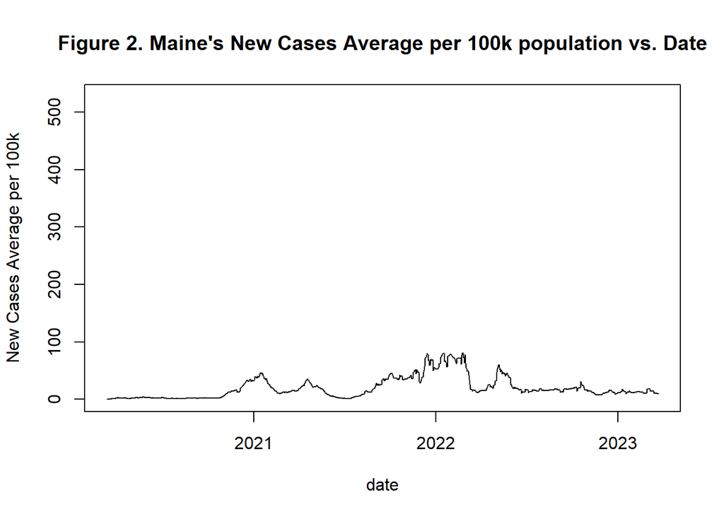

```r
with(covid_df[covid_df$state == "Maine", ], plot(cases_avg_per_100k ~ date, type = "l", ylim = c(min(covid_df$cases_avg_per_100k), max(covid_df$cases_avg_per_100k)), main = "Figure 2. Maine's New Cases Average per 100k population vs. Date", ylab = "New Cases Average per 100k"))
```

We should first find which state had the maximum average cases per population over time and the state with the minimum of that. To do that, I grouped over state and summed the cases_avg_per_100k from the data set and found that the maximum was Rhode Island and the minimum was Maine.

## c.

Let’s assume that if the average cases per 100 k population of 3 consecutive days is more than 20 is considered a substantial experience with covid for a particular state.

```r
substantial_test <- function(n, threshold = 20, day = 3){
  n2 <- c(n[-1], NA)
  n3 <- c(n2[-1], NA)
  avg <- apply(data.frame(n, n2, n3), 1, mean, na.rm = TRUE)
  result <- which(avg > threshold)[1]
  return(result)
}

states <- unique(covid_df$state)

first_experience <- vector(mode = "numeric", length = length(states))

for (i in 1:length(states)){
    first_experience[i] <- substantial_test(n = covid_df[covid_df$state == states[i],]$cases_avg_per_100k)
}

first_5 <- data.frame(states, first_experience) %>%
  arrange(first_experience) %>%
  head(5)
first_5$states
```

```
[1] "New York"    "Guam"        "Louisiana"   "New Jersey"  "Connecticut"
```

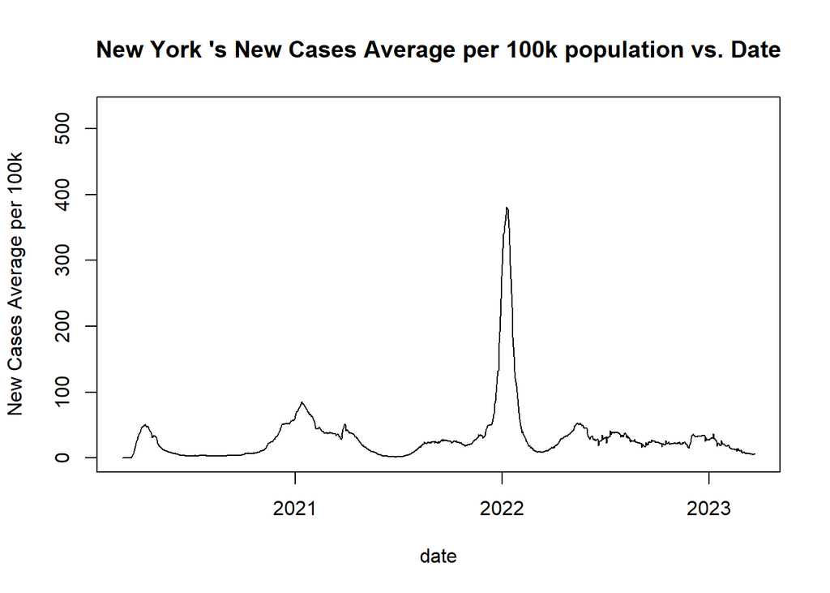

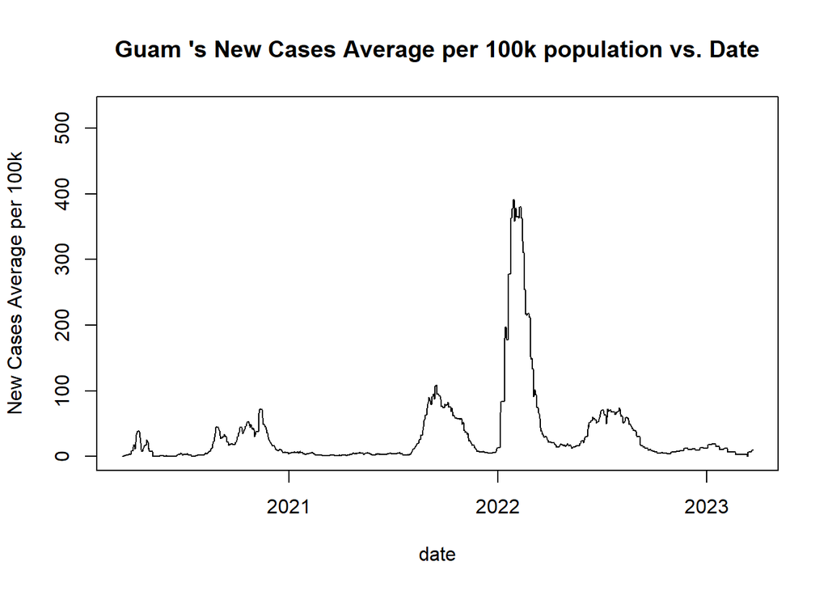

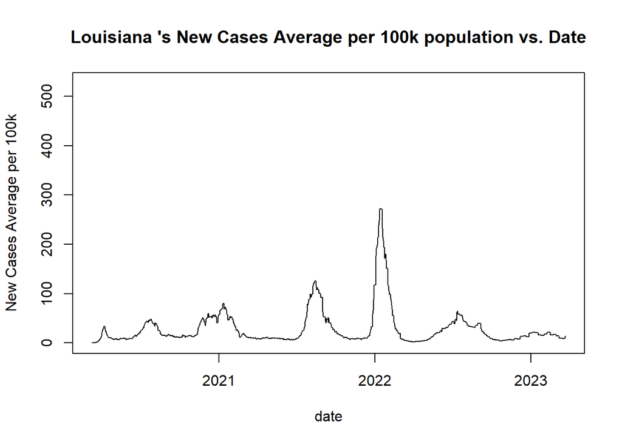

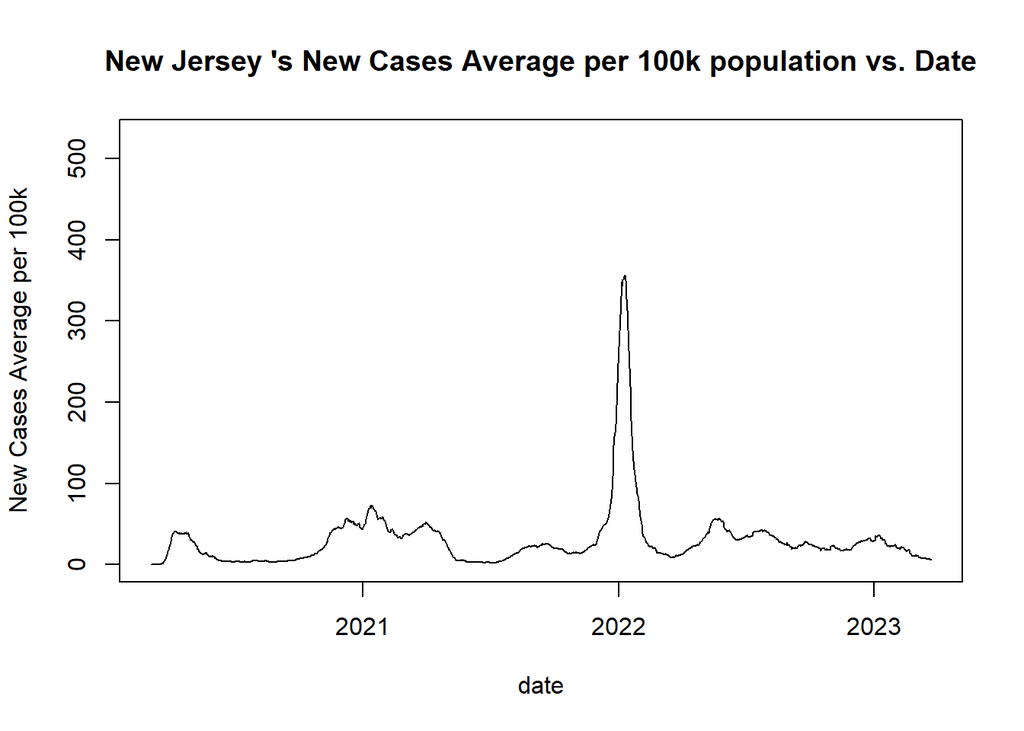

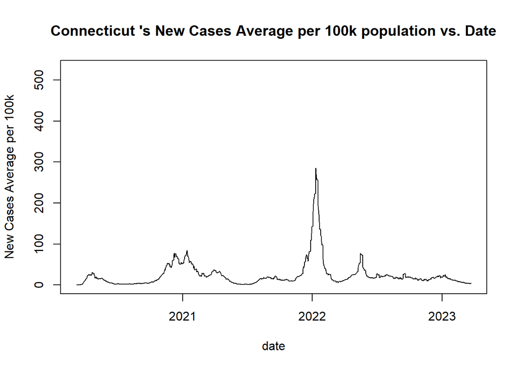

```r
for (i in first_5$states){
  with(covid_df[covid_df$state == i, ], plot(cases_avg_per_100k ~ date, type = "l", ylim = c(min(covid_df$cases_avg_per_100k), max(covid_df$cases_avg_per_100k)), main = paste(i, "'s New Cases Average per 100k population vs. Date"), ylab = "New Cases Average per 100k"))
}
```

The five states with the earliest substantial experience with covid are New York, Guam, Louisiana, New Jersey, and Connecticut up to our assumption.